# Comparison between one and two-sided tests

# Introduction

In many practical situations the aim of the study is establishing that values, such as HTA, drug level, etc in one group are bigger (or smaller) than those in another other group.

In such cases, we need to do a test with one-sided alternative. While it is straightforward to do in R, it is important to understand what we are doing because R will always provide an answer if we write the test in the right or in the wrong way.

For example, assume we have two groups, A and B, where we want to compare the mean value of some response variable. We believe that group B has higher values than those in group A.

## Simulated data

A situation where a one-sided alternative test is reasonable is simulated below..

Remember however *that we would not proceed looking at the data and then deciding that we want to do a one-sided test*. **Hypotheses need to be stated before data is collected**

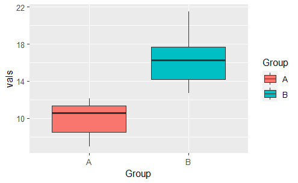

```r
x <- rnorm(10, mean=10, sd=3)
y <- rnorm(10, mean=15, sd=3)

grup <- as.factor(c(rep("A", 10), rep("B",10)))

myData <- data.frame(Group=grup, vals=c(x,y))

library(ggplot2)
ggplot(myData, aes(x=Group, y=vals, fill=Group)) +
  geom_boxplot()
```

# Testing to compare two means (or medians)

A reasonable hypothesis test:

$$H_0: m_A=m_B,\qquad H_1: m_A <
m_B$$

Where “m” may represent either the mean or the median of the response variable.

Assuming normality we can use a t.test. A two-sided version of this test is:

```r
t.test(vals~Group, data=myData)
```

```
    Welch Two Sample t-test

data:  vals by Group
t = -6.16, df = 15.495, p-value = 1.581e-05
alternative hypothesis: true difference in means between group A and group B is not equal to 0
95 percent confidence interval:
 -8.553635 -4.164996
sample estimates:
mean in group A mean in group B
       9.910679       16.269995
```

Now, realizing that we have a one-sided alternative *how should we write the alternative hypothesis*?

```r
t.test(vals~Group, data=myData,
       alternative="less")
```

or

```r
t.test(vals~Group, data=myData,
       alternative="greater")
```

Both writings might be acceptable, depending on if they mean “m1 is less than m2” or “m2 is greater than m1”

Indeed only one is correct. To know which one **we just have to think in terms of the first and the second group**, that is if we write

$$m_1 \mbox{ is ... than } m_2$$
it becomes clear that the word required to complete the sentence describing the alternative hypothesis is “less”.

Let’s check that it is so indeed:

If we do the test as described above:

```r
t.test(vals~Group, data=myData, alternative="less")
```

```
    Welch Two Sample t-test

data:  vals by Group
t = -6.16, df = 15.495, p-value = 7.904e-06
alternative hypothesis: true difference in means between group A and group B is less than 0
95 percent confidence interval:
      -Inf -4.553322
sample estimates:
mean in group A mean in group B
       9.910679       16.269995
```

We observe:

- Sample mean in group A is clearly smaller than that in group B.
- The p-value is very small
- The confidence interval does not cover 0, and it only has an upper limit. The null is rejected if m2 is greater enough than m1. We don’t care about m1 being too small because the alternative is one-sided, so there is no lower limit.

Now, imagine we do it wrong and write:

```r
t.test(vals~Group, data=myData, alternative="greater")
```

```
    Welch Two Sample t-test

data:  vals by Group
t = -6.16, df = 15.495, p-value = 1
alternative hypothesis: true difference in means between group A and group B is greater than 0
95 percent confidence interval:
 -8.165309       Inf
sample estimates:
mean in group A mean in group B
       9.910679       16.269995
```

- Notice that while there is a clear difference between the two means the p-value does not alloow rejecting the null hypothesis.
- What is worst, the confidence interval does not have an upper limit which means that we would never be able to reject the null even if the difference increased.

# In summary

When one is posing one-sided alternative tests using R to compare two groups, think of it in terms of stating the hypothesis writing the lower categories first.

For instance if the two groups are defined as “A” and “B” the hypothesis has to be stated in terms of

- “A equals B” vs “A less than B” (or “A greater than B”)
- **but not** “B greater than A” (or “B less than A”)